# Starbucks Capstone Challenge

### Introduction

This data set contains simulated data that mimics customer behavior on the Starbucks rewards mobile app. Once every few days, Starbucks sends out an offer to users of the mobile app. An offer can be merely an advertisement for a drink or an actual offer such as a discount or BOGO (buy one get one free). Some users might not receive any offer during certain weeks.

Not all users receive the same offer, and that is the challenge to solve with this data set.

Your task is to combine transaction, demographic and offer data to determine which demographic groups respond best to which offer type. This data set is a simplified version of the real Starbucks app because the underlying simulator only has one product whereas Starbucks actually sells dozens of products.

Every offer has a validity period before the offer expires. As an example, a BOGO offer might be valid for only 5 days. You'll see in the data set that informational offers have a validity period even though these ads are merely providing information about a product; for example, if an informational offer has 7 days of validity, you can assume the customer is feeling the influence of the offer for 7 days after receiving the advertisement.

You'll be given transactional data showing user purchases made on the app including the timestamp of purchase and the amount of money spent on a purchase. This transactional data also has a record for each offer that a user receives as well as a record for when a user actually views the offer. There are also records for when a user completes an offer.

Keep in mind as well that someone using the app might make a purchase through the app without having received an offer or seen an offer.

### Example

To give an example, a user could receive a discount offer buy 10 dollars get 2 off on Monday. The offer is valid for 10 days from receipt. If the customer accumulates at least 10 dollars in purchases during the validity period, the customer completes the offer.

However, there are a few things to watch out for in this data set. Customers do not opt into the offers that they receive; in other words, a user can receive an offer, never actually view the offer, and still complete the offer. For example, a user might receive the "buy 10 dollars get 2 dollars off offer", but the user never opens the offer during the 10 day validity period. The customer spends 15 dollars during those ten days. There will be an offer completion record in the data set; however, the customer was not influenced by the offer because the customer never viewed the offer.

### Cleaning

This makes data cleaning especially important and tricky.

You'll also want to take into account that some demographic groups will make purchases even if they don't receive an offer. From a business perspective, if a customer is going to make a 10 dollar purchase without an offer anyway, you wouldn't want to send a buy 10 dollars get 2 dollars off offer. You'll want to try to assess what a certain demographic group will buy when not receiving any offers.

### Final Advice

Because this is a capstone project, you are free to analyze the data any way you see fit. For example, you could build a machine learning model that predicts how much someone will spend based on demographics and offer type. Or you could build a model that predicts whether or not someone will respond to an offer. Or, you don't need to build a machine learning model at all. You could develop a set of heuristics that determine what offer you should send to each customer (i.e., 75 percent of women customers who were 35 years old responded to offer A vs 40 percent from the same demographic to offer B, so send offer A).

# Data Sets

The data is contained in three files:

- portfolio.json - containing offer ids and meta data about each offer (duration, type, etc.)
- profile.json - demographic data for each customer
- transcript.json - records for transactions, offers received, offers viewed, and offers completed

Here is the schema and explanation of each variable in the files:

**portfolio.json**

- id (string) - offer id
- offer_type (string) - type of offer ie BOGO, discount, informational
- difficulty (int) - minimum required spend to complete an offer
- reward (int) - reward given for completing an offer
- duration (int) - time for offer to be open, in days
- channels (list of strings)

**profile.json**

- age (int) - age of the customer
- became_member_on (int) - date when customer created an app account
- gender (str) - gender of the customer (note some entries contain 'O' for other rather than M or F)
- id (str) - customer id
- income (float) - customer's income

**transcript.json**

- event (str) - record description (ie transaction, offer received, offer viewed, etc.)
- person (str) - customer id
- time (int) - time in hours since start of test. The data begins at time t=0
- value - (dict of strings) - either an offer id or transaction amount depending on the record

**Note:** If you are using the workspace, you will need to go to the terminal and run the command `conda update pandas` before reading in the files. This is because the version of pandas in the workspace cannot read in the transcript.json file correctly, but the newest version of pandas can. You can access the termnal from the orange icon in the top left of this notebook.

You can see how to access the terminal and how the install works using the two images below. First you need to access the terminal:

[figure not shown]

Then you will want to run the above command:

[figure not shown]

Finally, when you enter back into the notebook (use the jupyter icon again), you should be able to run the below cell without any errors.

# Pkgs

```python
import pandas as pd
import numpy as np
import math
import json
import matplotlib.pyplot as plt
import seaborn as sns
import datetime as dt
import sqlite3
from sqlalchemy import create_engine

from sklearn.model_selection import train_test_split
from sklearn.preprocessing import StandardScaler, MinMaxScaler
from sklearn.linear_model import LinearRegression
from sklearn.ensemble import RandomForestRegressor
from sklearn.metrics import r2_score

import xgboost as xgb

import statsmodels.api as sm

#save models
import joblib

%matplotlib inline
```

```python
# read in the json files
portfolio = pd.read_json('data/portfolio.json', orient='records', lines=True)
profile = pd.read_json('data/profile.json', orient='records', lines=True)
transcript = pd.read_json('data/transcript.json', orient='records', lines=True)
```

# Data Overview

## porfolio

```python
portfolio
```

|  | reward | channels | difficulty | duration | offer_type | id |
| --- | --- | --- | --- | --- | --- | --- |
| 0 | 10 | [email, mobile, social] | 10 | 7 | bogo | ae264e3637204a6fb9bb56bc8210ddfd |
| 1 | 10 | [web, email, mobile, social] | 10 | 5 | bogo | 4d5c57ea9a6940dd891ad53e9dbe8da0 |
| 2 | 0 | [web, email, mobile] | 0 | 4 | informational | 3f207df678b143eea3cee63160fa8bed |
| 3 | 5 | [web, email, mobile] | 5 | 7 | bogo | 9b98b8c7a33c4b65b9aebfe6a799e6d9 |
| 4 | 5 | [web, email] | 20 | 10 | discount | 0b1e1539f2cc45b7b9fa7c272da2e1d7 |
| 5 | 3 | [web, email, mobile, social] | 7 | 7 | discount | 2298d6c36e964ae4a3e7e9706d1fb8c2 |
| 6 | 2 | [web, email, mobile, social] | 10 | 10 | discount | fafdcd668e3743c1bb461111dcafc2a4 |
| 7 | 0 | [email, mobile, social] | 0 | 3 | informational | 5a8bc65990b245e5a138643cd4eb9837 |
| 8 | 5 | [web, email, mobile, social] | 5 | 5 | bogo | f19421c1d4aa40978ebb69ca19b0e20d |
| 9 | 2 | [web, email, mobile] | 10 | 7 | discount | 2906b810c7d4411798c6938adc9daaa5 |

```python
portfolio.info()
```

```
<class 'pandas.core.frame.DataFrame'>
RangeIndex: 10 entries, 0 to 9
Data columns (total 6 columns):
reward        10 non-null int64
channels      10 non-null object
difficulty    10 non-null int64
duration      10 non-null int64
offer_type    10 non-null object
id            10 non-null object
dtypes: int64(3), object(3)
memory usage: 608.0+ bytes
```

```python
portfolio.describe()
```

|  | reward | difficulty | duration |
| --- | --- | --- | --- |
| count | 10.000000 | 10.000000 | 10.000000 |
| mean | 4.200000 | 7.700000 | 6.500000 |
| std | 3.583915 | 5.831905 | 2.321398 |
| min | 0.000000 | 0.000000 | 3.000000 |
| 25% | 2.000000 | 5.000000 | 5.000000 |
| 50% | 4.000000 | 8.500000 | 7.000000 |
| 75% | 5.000000 | 10.000000 | 7.000000 |
| max | 10.000000 | 20.000000 | 10.000000 |

## profile

```python
profile.head()
```

|  | gender | age | id | became_member_on | income |
| --- | --- | --- | --- | --- | --- |
| 0 | None | 118 | 68be06ca386d4c31939f3a4f0e3dd783 | 20170212 | NaN |
| 1 | F | 55 | 0610b486422d4921ae7d2bf64640c50b | 20170715 | 112000.0 |
| 2 | None | 118 | 38fe809add3b4fcf9315a9694bb96ff5 | 20180712 | NaN |
| 3 | F | 75 | 78afa995795e4d85b5d9ceeca43f5fef | 20170509 | 100000.0 |
| 4 | None | 118 | a03223e636434f42ac4c3df47e8bac43 | 20170804 | NaN |

```python
profile.info()
```

```
<class 'pandas.core.frame.DataFrame'>
RangeIndex: 17000 entries, 0 to 16999
Data columns (total 5 columns):
gender              14825 non-null object
age                 17000 non-null int64
id                  17000 non-null object
became_member_on    17000 non-null int64
income              14825 non-null float64
dtypes: float64(1), int64(2), object(2)
memory usage: 664.2+ KB
```

```python
profile.describe()
```

|  | age | became_member_on | income |
| --- | --- | --- | --- |
| count | 17000.000000 | 1.700000e+04 | 14825.000000 |
| mean | 62.531412 | 2.016703e+07 | 65404.991568 |
| std | 26.738580 | 1.167750e+04 | 21598.299410 |
| min | 18.000000 | 2.013073e+07 | 30000.000000 |
| 25% | 45.000000 | 2.016053e+07 | 49000.000000 |
| 50% | 58.000000 | 2.017080e+07 | 64000.000000 |
| 75% | 73.000000 | 2.017123e+07 | 80000.000000 |
| max | 118.000000 | 2.018073e+07 | 120000.000000 |

## transcript

```python
transcript.head()
```

|  | person | event | value | time |
| --- | --- | --- | --- | --- |
| 0 | 78afa995795e4d85b5d9ceeca43f5fef | offer received | {'offer id': '9b98b8c7a33c4b65b9aebfe6a799e6d9'} | 0 |
| 1 | a03223e636434f42ac4c3df47e8bac43 | offer received | {'offer id': '0b1e1539f2cc45b7b9fa7c272da2e1d7'} | 0 |
| 2 | e2127556f4f64592b11af22de27a7932 | offer received | {'offer id': '2906b810c7d4411798c6938adc9daaa5'} | 0 |
| 3 | 8ec6ce2a7e7949b1bf142def7d0e0586 | offer received | {'offer id': 'fafdcd668e3743c1bb461111dcafc2a4'} | 0 |
| 4 | 68617ca6246f4fbc85e91a2a49552598 | offer received | {'offer id': '4d5c57ea9a6940dd891ad53e9dbe8da0'} | 0 |

```python
transcript['event'].unique()
```

```
array(['offer received', 'offer viewed', 'transaction', 'offer completed'],
      dtype=object)
```

```python
df1 = transcript[transcript['event']=='offer received']
df2 = transcript[transcript['event']=='offer viewed']
df3 = transcript[transcript['event']=='transaction']
df4 = transcript[transcript['event']=='offer completed']
```

```python
df1.head()
```

|  | person | event | value | time |
| --- | --- | --- | --- | --- |
| 0 | 78afa995795e4d85b5d9ceeca43f5fef | offer received | {'offer id': '9b98b8c7a33c4b65b9aebfe6a799e6d9'} | 0 |
| 1 | a03223e636434f42ac4c3df47e8bac43 | offer received | {'offer id': '0b1e1539f2cc45b7b9fa7c272da2e1d7'} | 0 |
| 2 | e2127556f4f64592b11af22de27a7932 | offer received | {'offer id': '2906b810c7d4411798c6938adc9daaa5'} | 0 |
| 3 | 8ec6ce2a7e7949b1bf142def7d0e0586 | offer received | {'offer id': 'fafdcd668e3743c1bb461111dcafc2a4'} | 0 |
| 4 | 68617ca6246f4fbc85e91a2a49552598 | offer received | {'offer id': '4d5c57ea9a6940dd891ad53e9dbe8da0'} | 0 |

```python
df2.head()
```

|  | person | event | value | time |
| --- | --- | --- | --- | --- |
| 12650 | 389bc3fa690240e798340f5a15918d5c | offer viewed | {'offer id': 'f19421c1d4aa40978ebb69ca19b0e20d'} | 0 |
| 12651 | d1ede868e29245ea91818a903fec04c6 | offer viewed | {'offer id': '5a8bc65990b245e5a138643cd4eb9837'} | 0 |
| 12652 | 102e9454054946fda62242d2e176fdce | offer viewed | {'offer id': '4d5c57ea9a6940dd891ad53e9dbe8da0'} | 0 |
| 12653 | 02c083884c7d45b39cc68e1314fec56c | offer viewed | {'offer id': 'ae264e3637204a6fb9bb56bc8210ddfd'} | 0 |
| 12655 | be8a5d1981a2458d90b255ddc7e0d174 | offer viewed | {'offer id': '5a8bc65990b245e5a138643cd4eb9837'} | 0 |

```python
df3.head()
```

|  | person | event | value | time |
| --- | --- | --- | --- | --- |
| 12654 | 02c083884c7d45b39cc68e1314fec56c | transaction | {'amount': 0.8300000000000001} | 0 |
| 12657 | 9fa9ae8f57894cc9a3b8a9bbe0fc1b2f | transaction | {'amount': 34.56} | 0 |
| 12659 | 54890f68699049c2a04d415abc25e717 | transaction | {'amount': 13.23} | 0 |
| 12670 | b2f1cd155b864803ad8334cdf13c4bd2 | transaction | {'amount': 19.51} | 0 |
| 12671 | fe97aa22dd3e48c8b143116a8403dd52 | transaction | {'amount': 18.97} | 0 |

```python
df4.head()
```

|  | person | event | value | time |
| --- | --- | --- | --- | --- |
| 12658 | 9fa9ae8f57894cc9a3b8a9bbe0fc1b2f | offer completed | {'offer_id': '2906b810c7d4411798c6938adc9daaa5... | 0 |
| 12672 | fe97aa22dd3e48c8b143116a8403dd52 | offer completed | {'offer_id': 'fafdcd668e3743c1bb461111dcafc2a4... | 0 |
| 12679 | 629fc02d56414d91bca360decdfa9288 | offer completed | {'offer_id': '9b98b8c7a33c4b65b9aebfe6a799e6d9... | 0 |
| 12692 | 676506bad68e4161b9bbaffeb039626b | offer completed | {'offer_id': 'ae264e3637204a6fb9bb56bc8210ddfd... | 0 |
| 12697 | 8f7dd3b2afe14c078eb4f6e6fe4ba97d | offer completed | {'offer_id': '4d5c57ea9a6940dd891ad53e9dbe8da0... | 0 |

```python
transcript.info()
```

```
<class 'pandas.core.frame.DataFrame'>
RangeIndex: 306534 entries, 0 to 306533
Data columns (total 4 columns):
person    306534 non-null object
event     306534 non-null object
value     306534 non-null object
time      306534 non-null int64
dtypes: int64(1), object(3)
memory usage: 9.4+ MB
```

```python
transcript.describe()
```

|  | time |
| --- | --- |
| count | 306534.000000 |
| mean | 366.382940 |
| std | 200.326314 |
| min | 0.000000 |
| 25% | 186.000000 |
| 50% | 408.000000 |
| 75% | 528.000000 |
| max | 714.000000 |

```python
transcript['value'].apply(lambda x: list(x.values())[0])
```

```
0         9b98b8c7a33c4b65b9aebfe6a799e6d9
1         0b1e1539f2cc45b7b9fa7c272da2e1d7
2         2906b810c7d4411798c6938adc9daaa5
3         fafdcd668e3743c1bb461111dcafc2a4
4         4d5c57ea9a6940dd891ad53e9dbe8da0
                        ...
306529                                1.59
306530                                9.53
306531                                3.61
306532                                3.53
306533                                4.05
Name: value, Length: 306534, dtype: object
```

# Data Wrangling

## Assess

`portfolio`

- channels should be split into 4 columns 'web', 'email', 'mobile', 'social'；
- offer_type should be encoded with one-hot;
- id is too complex, should be reencoded，and change the name to 'promotion_id'；

`profile`

- gender has nan values；
- age has nan values(118)；
- became_member_on is date, the data format is not right；
- income has nan values；
- id is too complex, should be reencoded，and change the name to 'customer_id'；

`transcript`

- person and offer_id should be transformed into 'customer_id' and 'promotion_id'；
- Split data stored in dictionary format；
- 'event' contains 4 events, which should be split into 4 tables--'offer received', 'offer viewed', 'transaction', 'offer completed'；

## Clean

```python
# generate new id
def id_generator(data, original_id):
    """Generate a new id dict

    INPUT:
    data(dataframe) - a origin data frame

    OUTPUT:
    new_id_dict(dict) - new id dict
    """

    coded_dict = {}
    counter = 1

    for val in data[original_id]:
        if val not in coded_dict:
            coded_dict[val] = counter
            counter += 1

    return coded_dict
```

### portfolio

```python
# split channels
for item in ['web', 'email', 'mobile', 'social']:
    portfolio[item] = portfolio['channels'].apply(lambda x: 1 if item in x else 0)
portfolio.drop('channels', axis=1, inplace=True)
```

```python
#  generate new promotion id；
promotion_id_mapper = id_generator(portfolio, 'id')
portfolio['promotion_id'] = portfolio['id'].map(promotion_id_mapper)
portfolio.drop('id', axis=1, inplace=True)
```

```python
portfolio.head(10)
```

|  | reward | difficulty | duration | offer_type | web | email | mobile | social | promotion_id |
| --- | --- | --- | --- | --- | --- | --- | --- | --- | --- |
| 0 | 10 | 10 | 7 | bogo | 0 | 1 | 1 | 1 | 1 |
| 1 | 10 | 10 | 5 | bogo | 1 | 1 | 1 | 1 | 2 |
| 2 | 0 | 0 | 4 | informational | 1 | 1 | 1 | 0 | 3 |
| 3 | 5 | 5 | 7 | bogo | 1 | 1 | 1 | 0 | 4 |
| 4 | 5 | 20 | 10 | discount | 1 | 1 | 0 | 0 | 5 |
| 5 | 3 | 7 | 7 | discount | 1 | 1 | 1 | 1 | 6 |
| 6 | 2 | 10 | 10 | discount | 1 | 1 | 1 | 1 | 7 |
| 7 | 0 | 0 | 3 | informational | 0 | 1 | 1 | 1 | 8 |
| 8 | 5 | 5 | 5 | bogo | 1 | 1 | 1 | 1 | 9 |
| 9 | 2 | 10 | 7 | discount | 1 | 1 | 1 | 0 | 10 |

### profile

```python
# gender has nan values
profile['gender'].fillna('O', inplace=True)
```

```python
# age has invalid value 118；
median_age = profile[profile['age']<118]['age'].median()
profile['age'] = np.where(profile['age']==118, median_age, profile['age'])
```

```python
# became_member_on with wrong date format；
profile['became_member_on'] = profile['became_member_on'].apply(lambda x: dt.datetime.strptime(str(x), '%Y%m%d'))
profile['became_member_on'] = pd.to_datetime(profile['became_member_on'])
```

```python
# income has nan values
median_income = profile['income'].median()
profile['income'].fillna(median_income, inplace=True)
```

```python
# generate new customer id；
customer_id_mapper = id_generator(profile, 'id')
profile['customer_id'] = profile['id'].map(customer_id_mapper)
profile.drop('id', axis=1, inplace=True)
```

```python
profile.head()
```

|  | gender | age | became_member_on | income | customer_id |
| --- | --- | --- | --- | --- | --- |
| 0 | O | 55.0 | 2017-02-12 | 64000.0 | 1 |
| 1 | F | 55.0 | 2017-07-15 | 112000.0 | 2 |
| 2 | O | 55.0 | 2018-07-12 | 64000.0 | 3 |
| 3 | F | 75.0 | 2017-05-09 | 100000.0 | 4 |
| 4 | O | 55.0 | 2017-08-04 | 64000.0 | 5 |

### transcript

```python
# transform person into customer_id；
transcript['customer_id'] = transcript['person'].map(customer_id_mapper)
transcript.drop('person', axis=1, inplace=True)
```

```python
# split the value in dictionary；
transcript['value'] = transcript['value'].apply(lambda x: list(x.values())[0])
```

```python
# 'event' contains 4 events, which should be split into 4 tables--'offer received', 'offer viewed', 'transaction', 'offer completed'；
df_received = transcript[transcript['event']=='offer received']
df_viewed = transcript[transcript['event']=='offer viewed']
df_transaction = transcript[transcript['event']=='transaction']
df_completed = transcript[transcript['event']=='offer completed']
```

```python
# df_received clean
df_received['promotion_id'] = df_received['value'].map(promotion_id_mapper)
df_received.drop(['event','value'], axis=1, inplace=True)
df_received.reset_index(drop=True, inplace=True)
```

```python
df_received.head()
```

|  | time | customer_id | promotion_id |
| --- | --- | --- | --- |
| 0 | 0 | 4 | 4 |
| 1 | 0 | 5 | 5 |
| 2 | 0 | 6 | 10 |
| 3 | 0 | 7 | 7 |
| 4 | 0 | 8 | 2 |

```python
# df_viewed clean
df_viewed['promotion_id'] = df_viewed['value'].map(promotion_id_mapper)
df_viewed.drop(['event','value'], axis=1, inplace=True)
df_viewed.reset_index(drop=True, inplace=True)
```

```python
df_viewed.head()
```

|  | time | customer_id | promotion_id |
| --- | --- | --- | --- |
| 0 | 0 | 9 | 9 |
| 1 | 0 | 32 | 8 |
| 2 | 0 | 36 | 2 |
| 3 | 0 | 42 | 1 |
| 4 | 0 | 49 | 8 |

```python
# df_transaction clean
df_transaction['amount'] = df_transaction['value'].astype('float')
df_transaction.drop(['event','value'], axis=1, inplace=True)

df_transaction.reset_index(drop=True, inplace=True)
```

```python
df_transaction.head()
```

|  | time | customer_id | amount |
| --- | --- | --- | --- |
| 0 | 0 | 42 | 0.83 |
| 1 | 0 | 56 | 34.56 |
| 2 | 0 | 64 | 13.23 |
| 3 | 0 | 135 | 19.51 |
| 4 | 0 | 152 | 18.97 |

```python
# df_completed clean
df_completed['promotion_id'] = df_completed['value'].map(promotion_id_mapper)
df_completed.drop(['event','value'], axis=1, inplace=True)
df_completed.reset_index(drop=True, inplace=True)
```

```python
df_completed.head()
```

|  | time | customer_id | promotion_id |
| --- | --- | --- | --- |
| 0 | 0 | 56 | 10 |
| 1 | 0 | 152 | 7 |
| 2 | 0 | 175 | 4 |
| 3 | 0 | 300 | 1 |
| 4 | 0 | 317 | 2 |

# DataBase

Store the data into a database

```python
engine = create_engine('sqlite:///Starbucks.db')

conn = sqlite3.connect('Starbucks.db')
cur = conn.cursor()

cur.execute("DROP TABLE IF EXISTS portfolio")
portfolio.to_sql('portfolio', engine, index=False)

cur.execute("DROP TABLE IF EXISTS profile")
profile.to_sql('profile', engine, index=False)

cur.execute("DROP TABLE IF EXISTS offer_received")
df_received.to_sql('offer_received', engine, index=False)

cur.execute("DROP TABLE IF EXISTS offer_viewed")
df_viewed.to_sql('offer_viewed', engine, index=False)

cur.execute("DROP TABLE IF EXISTS offer_transaction")
df_transaction.to_sql('offer_transaction', engine, index=False)

cur.execute("DROP TABLE IF EXISTS offer_completed")
df_completed.to_sql('offer_completed', engine, index=False)
```

# EDA

```python
#  How many coupons will each user receive?
df_received.drop_duplicates(['customer_id', 'promotion_id']).groupby('customer_id')['promotion_id'].value_counts().values.max()
```

```
1
```

## Q1: How many users are there? How many users receive push messages? How many users have viewed the push information? How many users have purchase records? How many users have completed the push offer?

```python
profile.head()
```

|  | gender | age | became_member_on | income | customer_id |
| --- | --- | --- | --- | --- | --- |
| 0 | O | 55.0 | 2017-02-12 | 64000.0 | 1 |
| 1 | F | 55.0 | 2017-07-15 | 112000.0 | 2 |
| 2 | O | 55.0 | 2018-07-12 | 64000.0 | 3 |
| 3 | F | 75.0 | 2017-05-09 | 100000.0 | 4 |
| 4 | O | 55.0 | 2017-08-04 | 64000.0 | 5 |

```python
total_customer_num = profile['customer_id'].nunique()
print('There are {} customers in total'.format(total_customer_num))
```

```
There are 17000 customers in total
```

```python
df_received.head()
```

|  | time | customer_id | promotion_id |
| --- | --- | --- | --- |
| 0 | 0 | 4 | 4 |
| 1 | 0 | 5 | 5 |
| 2 | 0 | 6 | 10 |
| 3 | 0 | 7 | 7 |
| 4 | 0 | 8 | 2 |

```python
df_received['promotion_id'].value_counts()
```

```
4     7677
5     7668
1     7658
6     7646
10    7632
8     7618
3     7617
7     7597
2     7593
9     7571
Name: promotion_id, dtype: int64
```

```python
received_num = df_received['customer_id'].nunique()
received_ration =  round(100*received_num/total_customer_num, 2)
print('{} customers received the couponds, {}% of total customers'.format(received_num, received_ration))
```

```
16994 customers received the couponds, 99.96% of total customers
```

```python
viewed_num = df_viewed['customer_id'].nunique()
viewed_ration = round(100*viewed_num/received_num,2)
print('{} customers viewed the couponds, {}% of total received customers'.format(viewed_num, viewed_ration))
```

```
16834 customers viewed the couponds, 99.06% of total received customers
```

```python
transaction_num = df_transaction['customer_id'].nunique()
transaction_ration = round(100*transaction_num/viewed_num,2)
print('{} customers used the couponds, {}% of total viewed customers'.format(transaction_num, transaction_ration))
```

```
16578 customers used the couponds, 98.48% of total viewed customers
```

```python
completed_num = df_completed['customer_id'].nunique()
completed_ration = round(100*completed_num/transaction_num,2)
print('{} customers completed the couponds, {}% of total transaction customers'.format(completed_num, completed_ration))
```

```
12774 customers completed the couponds, 77.05% of total transaction customers
```

The conversion rate of each step is very good, but the last step needs to be improved;

## Q2: What is the average number and amount of consumption per user? What is the maximum consumption record?

```python
mean_transaction_cnt = round(df_transaction['customer_id'].value_counts().values.mean(),2)
max_transaction_cnt = df_transaction['customer_id'].value_counts().values.max()
print('The average consumption frequency is {}'.format(mean_transaction_cnt))
print('The largest consumption frequency is {}'.format(max_transaction_cnt))
```

```
The average consumption frequency is 8.38
The largest consumption frequency is 36
```

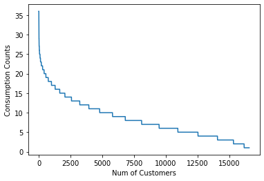

```python
plt.plot(df_transaction['customer_id'].value_counts().values)
plt.xlabel('Num of Customers')
plt.ylabel('Consumption Counts');
```

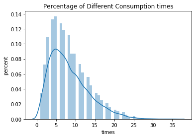

```python
g = sns.distplot(df_transaction['customer_id'].value_counts().values)

g.set(xlabel='times',ylabel= 'percent',title='Percentage of Different Consumption times');
```

```python
df_transaction['customer_id'].value_counts().values.mean()
```

```
8.381771021836169
```

## Q3: What is the return rate of consumers? What are the return rates for different push coupons?

```python
def row_number(data, partionby, orderby, ascending=True):
    """ Return the order data of each user's transactions
    INPUT:
    data(dataframe) - the data;
    partionby - divide data into different group based on partionby;
    orderby - sort the values based on orderby;
    ascending - the final data will rank ascending by default;

    OUTPUT:
    df_rn - the original dataframe with 1 new column rn
    """
    data_new = data.copy()
    data_new['rn'] = data_new[orderby].groupby(data_new[partionby]).rank(ascending=ascending, method='first')

    return data_new
```

```python
def first_2_transactions(data):
    """ Return the records of the first two transactions of each user
    INPUT：
    data(dataframe) - the original data;

    OUTPUT:
    df_first_2_transaction(dataframe) - with the first 2 times transaction records
    """
    df_rn = row_number(data, 'customer_id', 'time', True)

    df_top1 = df_rn[df_rn['rn']==1]
    df_top1.set_index('customer_id', inplace=True)
    df_top1 = df_top1[['time']]
    df_top1.rename(columns={'time':'first_time'}, inplace=True)

    df_top2 = df_rn[df_rn['rn']==2]
    df_top2.set_index('customer_id', inplace=True)
    df_top2 = df_top2[['time']]
    df_top2.rename(columns={'time':'second_time'}, inplace=True)

    df_first_2_transaction = df_top1.join(df_top2, how='outer')
    df_first_2_transaction['duration'] = df_first_2_transaction['second_time'] - df_first_2_transaction['first_time']
    df_first_2_transaction.sort_values('duration', inplace=True)
    return df_first_2_transaction
```

```python
def display_back_rate(data):
    """Calculate back rate
    INPUT：
    data(dataframe) - the original data;

    OUTPUT:
    back_rate(percentage) - return rate
    """
    df_total_top2 = first_2_transactions(data)
    come_back_num = df_total_top2['second_time'].notnull().sum()
    total_num = df_total_top2.shape[0]
    back_rate = round(100*come_back_num/total_num, 2)
    return back_rate
```

```python
# the average back_rate of users
display_back_rate(df_transaction)
```

```
97.58
```

```python
# calculate the back rate of different offer_type
promotion_list = list(df_received['promotion_id'].drop_duplicates())

result = []
for promotion_id in promotion_list:
    df_received_sub = df_received[df_received['promotion_id']==promotion_id]
    customer_list = list(df_received_sub['customer_id'].drop_duplicates())
    df_transaction_sub = df_transaction[df_transaction['customer_id'].isin(customer_list)]
    back_rate = display_back_rate(df_transaction_sub)
    result.append({
        'promotion_id': promotion_id,
        'return_rate': back_rate
    })
df_back_rate = pd.DataFrame(result, columns=['promotion_id', 'return_rate'])
```

```python
df_back_rate.sort_values('return_rate')
```

|  | promotion_id | return_rate |
| --- | --- | --- |
| 0 | 4 | 97.31 |
| 2 | 10 | 97.36 |
| 7 | 3 | 97.36 |
| 1 | 5 | 97.61 |
| 4 | 2 | 97.65 |
| 3 | 7 | 97.68 |
| 9 | 8 | 97.70 |
| 6 | 6 | 97.78 |
| 5 | 9 | 97.81 |
| 8 | 1 | 97.84 |

## Q4: What is the average consumption level of each voucher?

```python
def display_mean_gmv(data):
    """Calculate the mean gmv
    INPUT：
    data(dataframe) - the original data;

    OUTPUT:
    mean_gmv(percentage) - mean comsumption amount
    """
    mean_gmv = round(data['amount'].mean(), 2)
    return mean_gmv
```

```python
# calculate the mean_gmv of different offer_type
promotion_list = list(df_received['promotion_id'].drop_duplicates())

result = []
for promotion_id in promotion_list:
    df_received_sub = df_received[df_received['promotion_id']==promotion_id]
    customer_list = list(df_received_sub['customer_id'].drop_duplicates())
    df_transaction_sub = df_transaction[df_transaction['customer_id'].isin(customer_list)]
    mean_gmv = display_mean_gmv(df_transaction_sub)
    result.append({
        'promotion_id': promotion_id,
        'mean_gmv': mean_gmv
    })
df_mean_gmv = pd.DataFrame(result, columns=['promotion_id', 'mean_gmv'])
```

```python
df_mean_gmv.sort_values('mean_gmv')
```

|  | promotion_id | mean_gmv |
| --- | --- | --- |
| 4 | 2 | 12.54 |
| 6 | 6 | 12.63 |
| 3 | 7 | 12.70 |
| 0 | 4 | 12.73 |
| 8 | 1 | 12.75 |
| 5 | 9 | 12.77 |
| 2 | 10 | 12.82 |
| 7 | 3 | 12.82 |
| 9 | 8 | 12.94 |
| 1 | 5 | 13.00 |

- The back rate of promotion_id=1 is the most largest one , and it's 97.845%；
- The mean gmv of promotion_id=5 is the most largest one , and it's 13；

## Q5: With the change of age, gender and membership time of users, what is the change of return rate and consumption level?

```python
df_transaction_with_profile = pd.merge(df_transaction, profile, how='left', on=['customer_id'])
df_transaction_with_profile.head()
```

|  | time | customer_id | amount | gender | age | became_member_on | income |
| --- | --- | --- | --- | --- | --- | --- | --- |
| 0 | 0 | 42 | 0.83 | F | 20.0 | 2016-07-11 | 30000.0 |
| 1 | 0 | 56 | 34.56 | M | 42.0 | 2016-01-17 | 96000.0 |
| 2 | 0 | 64 | 13.23 | M | 36.0 | 2017-12-28 | 56000.0 |
| 3 | 0 | 135 | 19.51 | F | 55.0 | 2017-10-16 | 94000.0 |
| 4 | 0 | 152 | 18.97 | F | 39.0 | 2017-12-17 | 67000.0 |

```python
# calculate the member_duration_days
df_transaction_with_profile['member_duration_days'] = df_transaction_with_profile['became_member_on']-df_transaction_with_profile['became_member_on'].min()
df_transaction_with_profile['member_duration_days'] = df_transaction_with_profile['member_duration_days'].dt.days
```

```python
df_transaction_with_profile.head()
```

|  | time | customer_id | amount | gender | age | became_member_on | income | member_duration_days |
| --- | --- | --- | --- | --- | --- | --- | --- | --- |
| 0 | 0 | 42 | 0.83 | F | 20.0 | 2016-07-11 | 30000.0 | 1078 |
| 1 | 0 | 56 | 34.56 | M | 42.0 | 2016-01-17 | 96000.0 | 902 |
| 2 | 0 | 64 | 13.23 | M | 36.0 | 2017-12-28 | 56000.0 | 1613 |
| 3 | 0 | 135 | 19.51 | F | 55.0 | 2017-10-16 | 94000.0 | 1540 |
| 4 | 0 | 152 | 18.97 | F | 39.0 | 2017-12-17 | 67000.0 | 1602 |

```python
# split age, member_duration_days into groups
df_transaction_with_profile['age_cut'] = round(df_transaction_with_profile['age']/5, 0)*5
df_transaction_with_profile['member_duration_days_cut'] = round(df_transaction_with_profile['member_duration_days']/100, 0)*100
```

```python
df_transaction_with_profile.describe()
```

|  | time | customer_id | amount | age | income | member_duration_days | age_cut | member_duration_days_cut |
| --- | --- | --- | --- | --- | --- | --- | --- | --- |
| count | 138953.000000 | 138953.000000 | 138953.000000 | 138953.000000 | 138953.000000 | 138953.000000 | 138953.000000 | 138953.000000 |
| mean | 381.584334 | 8506.315416 | 12.777356 | 52.960677 | 62076.241607 | 1196.920944 | 52.990328 | 1196.833462 |
| std | 201.697230 | 4901.043065 | 30.250529 | 16.927692 | 19526.596899 | 430.304371 | 16.965764 | 431.458479 |
| min | 0.000000 | 1.000000 | 0.050000 | 18.000000 | 30000.000000 | 0.000000 | 20.000000 | 0.000000 |
| 25% | 210.000000 | 4278.000000 | 2.780000 | 41.000000 | 48000.000000 | 918.000000 | 40.000000 | 900.000000 |
| 50% | 402.000000 | 8517.000000 | 8.890000 | 55.000000 | 63000.000000 | 1276.000000 | 55.000000 | 1300.000000 |
| 75% | 552.000000 | 12724.000000 | 18.070000 | 64.000000 | 72000.000000 | 1547.000000 | 65.000000 | 1500.000000 |
| max | 714.000000 | 17000.000000 | 1062.280000 | 101.000000 | 120000.000000 | 1823.000000 | 100.000000 | 1800.000000 |

```python
def promotion_difference(data, column, val):
    """Calculate back rate, transaction times and mean gmv of didderent promotion.
    INPUT：
    data(dataframe) - the original data;
    column(col) - the specific column of the dataframe
    val(value) - the subset of users when 'column=val'

    OUTPUT:
    df_result(dataframe) - dataframes with back rate, transaction times and mean gmv of didderent promotion
    """
    df_transaction_temp = data[data[column]==val]
    promotion_list = list(df_received['promotion_id'].drop_duplicates())

    result = []
    for promotion_id in promotion_list:
        df_received_sub = df_received[df_received['promotion_id']==promotion_id]
        customer_list = list(df_received_sub['customer_id'].drop_duplicates())
        df_transaction_sub = df_transaction_temp[df_transaction_temp['customer_id'].isin(customer_list)]

        mean_transaction_cnt = df_transaction_sub['customer_id'].value_counts().values.mean()
        back_rate = display_back_rate(df_transaction_sub)
        mean_gmv = display_mean_gmv(df_transaction_sub)
        result.append({
            'column': column,
            'val': val,
            'promotion_id': promotion_id,
            'transaction_cnt': mean_transaction_cnt,
            'back_rate': back_rate,
            'mean_gmv': mean_gmv
        })
    df_result = pd.DataFrame(result, columns=['column', 'val', 'promotion_id', 'transaction_cnt', 'back_rate', 'mean_gmv'])
    return df_result
```

### Age

```python
age_cut_list = list(df_transaction_with_profile['age_cut'].drop_duplicates())

df_full_age = pd.DataFrame()
for age in age_cut_list:
    df_age = promotion_difference(df_transaction_with_profile, 'age_cut', age)
    df_full_age = df_full_age.append(df_age)
```

```python
df_full_age_with_portfolio = pd.merge(df_full_age, portfolio, how='left', on=['promotion_id'])
df_full_age_with_portfolio.rename(columns={'val': 'age'}, inplace=True)
df_full_age_with_portfolio.head(10)
```

|  | column | age | promotion_id | transaction_cnt | back_rate | mean_gmv | reward | difficulty | duration | offer_type | web | email | mobile | social |
| --- | --- | --- | --- | --- | --- | --- | --- | --- | --- | --- | --- | --- | --- | --- |
| 0 | age_cut | 20.0 | 4 | 9.609302 | 98.60 | 7.30 | 5 | 5 | 7 | bogo | 1 | 1 | 1 | 0 |
| 1 | age_cut | 20.0 | 5 | 9.427136 | 98.99 | 9.19 | 5 | 20 | 10 | discount | 1 | 1 | 0 | 0 |
| 2 | age_cut | 20.0 | 10 | 9.297071 | 98.74 | 8.38 | 2 | 10 | 7 | discount | 1 | 1 | 1 | 0 |
| 3 | age_cut | 20.0 | 7 | 11.004739 | 98.58 | 7.68 | 2 | 10 | 10 | discount | 1 | 1 | 1 | 1 |
| 4 | age_cut | 20.0 | 2 | 10.483051 | 98.73 | 7.99 | 10 | 10 | 5 | bogo | 1 | 1 | 1 | 1 |
| 5 | age_cut | 20.0 | 9 | 10.603448 | 98.28 | 7.88 | 5 | 5 | 5 | bogo | 1 | 1 | 1 | 1 |
| 6 | age_cut | 20.0 | 6 | 10.600840 | 99.58 | 8.16 | 3 | 7 | 7 | discount | 1 | 1 | 1 | 1 |
| 7 | age_cut | 20.0 | 3 | 9.944954 | 99.54 | 8.89 | 0 | 0 | 4 | informational | 1 | 1 | 1 | 0 |
| 8 | age_cut | 20.0 | 1 | 11.346154 | 99.52 | 8.62 | 10 | 10 | 7 | bogo | 0 | 1 | 1 | 1 |
| 9 | age_cut | 20.0 | 8 | 9.626556 | 99.59 | 8.89 | 0 | 0 | 3 | informational | 0 | 1 | 1 | 1 |

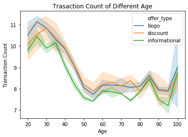

```python
# the trend of transaction count of different age
g = sns.lineplot(x="age", y="transaction_cnt",
             hue="offer_type",
             data=df_full_age_with_portfolio)

g.set(xlabel='Age',ylabel='Transaction Count',title='Trasaction Count of Different Age');
```

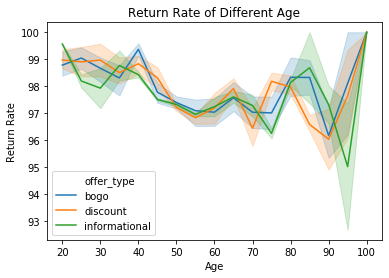

```python
# the trend of back rate of different age
g = sns.lineplot(x="age", y="back_rate",
             hue="offer_type",
             data=df_full_age_with_portfolio)

g.set(xlabel='Age',ylabel='Return Rate',title='Return Rate of Different Age');
```

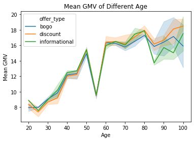

```python
# the trend of mean gmv of different age
g = sns.lineplot(x="age", y="mean_gmv",
             hue="offer_type",
             data=df_full_age_with_portfolio)

g.set(xlabel='Age',ylabel='Mean GMV',title='Mean GMV of Different Age');
```

### Gender

```python
gender_list = list(df_transaction_with_profile['gender'].drop_duplicates())

df_full_gender = pd.DataFrame()
for gender in gender_list:
    df_gender = promotion_difference(df_transaction_with_profile, 'gender', gender)
    df_full_gender = df_full_gender.append(df_gender)
```

```python
df_full_gender = pd.merge(df_full_gender, portfolio, how='left', on=['promotion_id'])
df_full_gender.rename(columns={'val': 'gender'}, inplace=True)
df_full_gender.head(10)
```

|  | column | gender | promotion_id | transaction_cnt | back_rate | mean_gmv | reward | difficulty | duration | offer_type | web | email | mobile | social |
| --- | --- | --- | --- | --- | --- | --- | --- | --- | --- | --- | --- | --- | --- | --- |
| 0 | gender | F | 4 | 8.334223 | 97.33 | 17.38 | 5 | 5 | 7 | bogo | 1 | 1 | 1 | 0 |
| 1 | gender | F | 5 | 8.009653 | 97.37 | 17.31 | 5 | 20 | 10 | discount | 1 | 1 | 0 | 0 |
| 2 | gender | F | 10 | 8.230072 | 97.51 | 17.47 | 2 | 10 | 7 | discount | 1 | 1 | 1 | 0 |
| 3 | gender | F | 7 | 9.005880 | 97.51 | 17.26 | 2 | 10 | 10 | discount | 1 | 1 | 1 | 1 |
| 4 | gender | F | 2 | 8.482634 | 97.65 | 17.31 | 10 | 10 | 5 | bogo | 1 | 1 | 1 | 1 |
| 5 | gender | F | 9 | 8.456452 | 97.45 | 17.75 | 5 | 5 | 5 | bogo | 1 | 1 | 1 | 1 |
| 6 | gender | F | 6 | 8.748302 | 97.65 | 17.49 | 3 | 7 | 7 | discount | 1 | 1 | 1 | 1 |
| 7 | gender | F | 3 | 8.062081 | 97.28 | 17.53 | 0 | 0 | 4 | informational | 1 | 1 | 1 | 0 |
| 8 | gender | F | 1 | 8.667113 | 97.72 | 17.38 | 10 | 10 | 7 | bogo | 0 | 1 | 1 | 1 |
| 9 | gender | F | 8 | 8.154117 | 97.62 | 17.72 | 0 | 0 | 3 | informational | 0 | 1 | 1 | 1 |

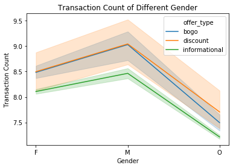

```python
# the trend of transaction count of different gender
g = sns.lineplot(x="gender", y="transaction_cnt",
             hue="offer_type",
             data=df_full_gender)

g.set(xlabel='Gender',ylabel='Transaction Count',title='Transaction Count of Different Gender');
```

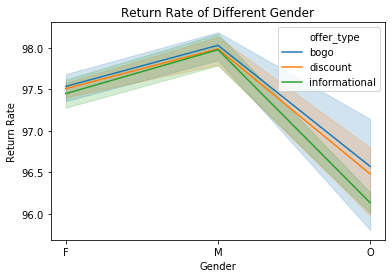

```python
# the trend of back rate of different age
g = sns.lineplot(x="gender", y="back_rate",
             hue="offer_type",
             data=df_full_gender)

g.set(xlabel='Gender',ylabel='Return Rate',title='Return Rate of Different Gender');
```

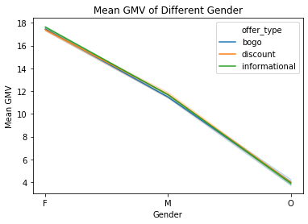

```python
# the trend of mean gmv of different age
g = sns.lineplot(x="gender", y="mean_gmv",
             hue="offer_type",
             data=df_full_gender)

g.set(xlabel='Gender',ylabel='Mean GMV',title='Mean GMV of Different Gender');
```

### Membership Duration

```python
member_duration_days_cut_list = list(df_transaction_with_profile['member_duration_days_cut'].drop_duplicates())

df_full_member_duration_days = pd.DataFrame()
for member_duration_days in member_duration_days_cut_list:
    df_member_duration_days = promotion_difference(df_transaction_with_profile, 'member_duration_days_cut', member_duration_days)
    df_full_member_duration_days = df_full_member_duration_days.append(df_member_duration_days)
```

```python
df_full_member_duration_days_with_portfolio = pd.merge(df_full_member_duration_days, portfolio, how='left', on=['promotion_id'])
df_full_member_duration_days_with_portfolio.rename(columns={'val': 'member_duration_days'}, inplace=True)
df_full_member_duration_days_with_portfolio.head(10)
```

|  | column | member_duration_days | promotion_id | transaction_cnt | back_rate | mean_gmv | reward | difficulty | duration | offer_type | web | email | mobile | social |
| --- | --- | --- | --- | --- | --- | --- | --- | --- | --- | --- | --- | --- | --- | --- |
| 0 | member_duration_days_cut | 1100.0 | 4 | 9.956113 | 99.37 | 15.69 | 5 | 5 | 7 | bogo | 1 | 1 | 1 | 0 |
| 1 | member_duration_days_cut | 1100.0 | 5 | 9.835938 | 99.22 | 15.65 | 5 | 20 | 10 | discount | 1 | 1 | 0 | 0 |
| 2 | member_duration_days_cut | 1100.0 | 10 | 10.119760 | 99.40 | 15.43 | 2 | 10 | 7 | discount | 1 | 1 | 1 | 0 |
| 3 | member_duration_days_cut | 1100.0 | 7 | 11.525074 | 99.41 | 15.28 | 2 | 10 | 10 | discount | 1 | 1 | 1 | 1 |
| 4 | member_duration_days_cut | 1100.0 | 2 | 10.577465 | 99.44 | 14.30 | 10 | 10 | 5 | bogo | 1 | 1 | 1 | 1 |
| 5 | member_duration_days_cut | 1100.0 | 9 | 10.396552 | 99.71 | 14.94 | 5 | 5 | 5 | bogo | 1 | 1 | 1 | 1 |
| 6 | member_duration_days_cut | 1100.0 | 6 | 11.036313 | 99.72 | 14.84 | 3 | 7 | 7 | discount | 1 | 1 | 1 | 1 |
| 7 | member_duration_days_cut | 1100.0 | 3 | 9.922619 | 99.11 | 15.39 | 0 | 0 | 4 | informational | 1 | 1 | 1 | 0 |
| 8 | member_duration_days_cut | 1100.0 | 1 | 10.438202 | 99.44 | 15.79 | 10 | 10 | 7 | bogo | 0 | 1 | 1 | 1 |
| 9 | member_duration_days_cut | 1100.0 | 8 | 9.749304 | 99.72 | 15.01 | 0 | 0 | 3 | informational | 0 | 1 | 1 | 1 |

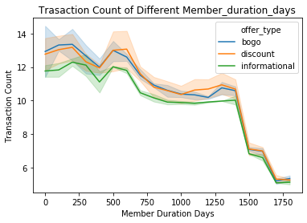

```python
# the trend of transaction count of different member duration
g = sns.lineplot(x="member_duration_days", y="transaction_cnt",
             hue="offer_type",
             data=df_full_member_duration_days_with_portfolio)

g.set(xlabel='Member Duration Days',ylabel='Transaction Count',title='Trasaction Count of Different Member_duration_days');
```

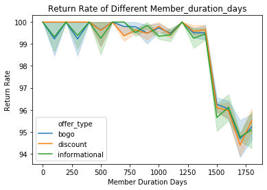

```python
# the trend of back rate of different member duration
g = sns.lineplot(x="member_duration_days", y="back_rate",
             hue="offer_type",
             data=df_full_member_duration_days_with_portfolio)

g.set(xlabel='Member Duration Days',ylabel='Return Rate',title='Return Rate of Different Member_duration_days');
```

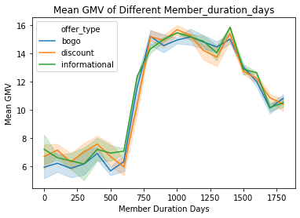

```python
# the trend of mean gmv of different member duration
g = sns.lineplot(x="member_duration_days", y="mean_gmv",
             hue="offer_type",
             data=df_full_member_duration_days_with_portfolio)

g.set(xlabel='Member Duration Days',ylabel='Mean GMV',title='Mean GMV of Different Member_duration_days');
```

## Summary

-**Gender**: male consumers have higher consumption frequency and reflow speed, while female consumers have higher single average consumption;

-**Member Duration**: the frequency of consumption decreased three times, 250 days, 600 days and 1400 days after becoming a member respectively; the speed of backflow also decreased significantly after becoming a member 1400 days; the average consumption level of members from 750 days to 1400 days was the highest;

-Compared with information, BOGO and discount can improve consumption frequency and reflow speed, but they have no significant effect on the average consumption;

-Discount has more advantages than BOGO in increasing consumption frequency; BOGO has more advantages in promoting consumer return; if the goal of the business is to let more consumers buy, reflecting prosperity, discount is a good overall strategy, but if in the short term, increasing the probability of consumer return, BOGO is a more correct choice;

# Forecast the total consumption of each person in different push modes

## Data

```python
# Info of push messages received
df_received_info = df_received.drop_duplicates(['customer_id', 'promotion_id'])
df_received_info.drop('time', axis=1, inplace=True)
df_received_info.head()
```

|  | customer_id | promotion_id |
| --- | --- | --- |
| 0 | 4 | 4 |
| 1 | 5 | 5 |
| 2 | 6 | 10 |
| 3 | 7 | 7 |
| 4 | 8 | 2 |

```python
# Number of push messages received
df_received_cnt = df_received.groupby(['customer_id', 'promotion_id']).count()
df_received_cnt.reset_index(inplace=True)
df_received_cnt.rename(columns={'time':'received_cnt'}, inplace=True)

df_received_cnt.head()
```

|  | customer_id | promotion_id | received_cnt |
| --- | --- | --- | --- |
| 0 | 1 | 5 | 1 |
| 1 | 1 | 6 | 1 |
| 2 | 1 | 7 | 2 |
| 3 | 1 | 10 | 1 |
| 4 | 2 | 3 | 1 |

```python
# View push information times
df_viewed_cnt = df_viewed.groupby(['customer_id', 'promotion_id']).count()
df_viewed_cnt.reset_index(inplace=True)
df_viewed_cnt.rename(columns={'time':'viewed_cnt'}, inplace=True)

df_viewed_cnt.head()
```

|  | customer_id | promotion_id | viewed_cnt |
| --- | --- | --- | --- |
| 0 | 1 | 5 | 1 |
| 1 | 1 | 6 | 1 |
| 2 | 1 | 7 | 2 |
| 3 | 1 | 10 | 1 |
| 4 | 3 | 4 | 1 |

```python
# Number and total consumption level of each consumer
gp = df_transaction.groupby(['customer_id'])['amount']

df_customer_transaction = pd.DataFrame()
df_customer_transaction['consumption_cnt'] = gp.count()
df_customer_transaction['consumption_amount'] = gp.sum()
df_customer_transaction['consumption_avg'] = df_customer_transaction['consumption_amount']/df_customer_transaction['consumption_cnt']

df_customer_transaction.reset_index(inplace=True)
```

```python
df_customer_transaction.head()
```

|  | customer_id | consumption_cnt | consumption_amount | consumption_avg |
| --- | --- | --- | --- | --- |
| 0 | 1 | 9 | 20.40 | 2.266667 |
| 1 | 2 | 3 | 77.01 | 25.670000 |
| 2 | 3 | 6 | 14.30 | 2.383333 |
| 3 | 4 | 7 | 159.27 | 22.752857 |
| 4 | 5 | 3 | 4.65 | 1.550000 |

```python
# merge data
df_all = pd.merge(df_received_info, profile, how='left', on=['customer_id'])
df_all = pd.merge(df_all, portfolio, how='left', on=['promotion_id'])
df_all = pd.merge(df_all, df_received_info, how='left', on=['customer_id', 'promotion_id'])
df_all = pd.merge(df_all, df_received_cnt, how='left', on=['customer_id', 'promotion_id'])
df_all = pd.merge(df_all, df_viewed_cnt, how='left', on=['customer_id', 'promotion_id'])
df_all = pd.merge(df_all, df_customer_transaction, how='left', on=['customer_id'])

df_all.head()
```

|  | customer_id | promotion_id | gender | age | became_member_on | income | reward | difficulty | duration | offer_type | web | email | mobile | social | received_cnt | viewed_cnt | consumption_cnt | consumption_amount | consumption_avg |
| --- | --- | --- | --- | --- | --- | --- | --- | --- | --- | --- | --- | --- | --- | --- | --- | --- | --- | --- | --- |
| 0 | 4 | 4 | F | 75.0 | 2017-05-09 | 100000.0 | 5 | 5 | 7 | bogo | 1 | 1 | 1 | 0 | 1 | 1.0 | 7.0 | 159.27 | 22.752857 |
| 1 | 5 | 5 | O | 55.0 | 2017-08-04 | 64000.0 | 5 | 20 | 10 | discount | 1 | 1 | 0 | 0 | 3 | 2.0 | 3.0 | 4.65 | 1.550000 |
| 2 | 6 | 10 | M | 68.0 | 2018-04-26 | 70000.0 | 2 | 10 | 7 | discount | 1 | 1 | 1 | 0 | 1 | 1.0 | 3.0 | 57.73 | 19.243333 |
| 3 | 7 | 7 | O | 55.0 | 2017-09-25 | 64000.0 | 2 | 10 | 10 | discount | 1 | 1 | 1 | 1 | 2 | 2.0 | NaN | NaN | NaN |
| 4 | 8 | 2 | O | 55.0 | 2017-10-02 | 64000.0 | 10 | 10 | 5 | bogo | 1 | 1 | 1 | 1 | 1 | 1.0 | 2.0 | 0.24 | 0.120000 |

```python
data = df_all.copy()

# Using one hot code to process gender
data = pd.get_dummies(data, columns = ['gender', 'offer_type'])

# change became member on to days
data['member_duration_days'] = data['became_member_on']-data['became_member_on'].min()
data['member_duration_days'] = data['member_duration_days'].dt.days

# keep the main columns
columns_to_keep = ['age', 'income', 'reward', 'difficulty', 'duration', 'web', 'email', 'mobile', 'social', \
                  'received_cnt', 'viewed_cnt', 'gender_F', 'gender_M',\
                  'offer_type_bogo', 'offer_type_discount', 'offer_type_informational', 'member_duration_days', 'consumption_amount', 'consumption_avg']

data = data[columns_to_keep]
data.fillna(0, inplace=True)

# Only consider consumers with consumption records
data = data[data['consumption_amount']>0]
```

```python
data.head()
```

|  | age | income | reward | difficulty | duration | web | email | mobile | social | received_cnt | viewed_cnt | gender_F | gender_M | offer_type_bogo | offer_type_discount | offer_type_informational | member_duration_days | consumption_amount | consumption_avg |
| --- | --- | --- | --- | --- | --- | --- | --- | --- | --- | --- | --- | --- | --- | --- | --- | --- | --- | --- | --- |
| 0 | 75.0 | 100000.0 | 5 | 5 | 7 | 1 | 1 | 1 | 0 | 1 | 1.0 | 1 | 0 | 1 | 0 | 0 | 1380 | 159.27 | 22.752857 |
| 1 | 55.0 | 64000.0 | 5 | 20 | 10 | 1 | 1 | 0 | 0 | 3 | 2.0 | 0 | 0 | 0 | 1 | 0 | 1467 | 4.65 | 1.550000 |
| 2 | 68.0 | 70000.0 | 2 | 10 | 7 | 1 | 1 | 1 | 0 | 1 | 1.0 | 0 | 1 | 0 | 1 | 0 | 1732 | 57.73 | 19.243333 |
| 4 | 55.0 | 64000.0 | 10 | 10 | 5 | 1 | 1 | 1 | 1 | 1 | 1.0 | 0 | 0 | 1 | 0 | 0 | 1526 | 0.24 | 0.120000 |
| 5 | 65.0 | 53000.0 | 5 | 5 | 5 | 1 | 1 | 1 | 1 | 2 | 2.0 | 0 | 1 | 1 | 0 | 0 | 1656 | 36.43 | 12.143333 |

## Outliers

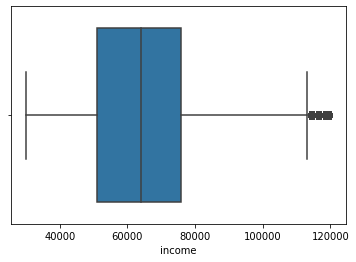

```python
# income
sns.boxplot(x='income',data=data);
```

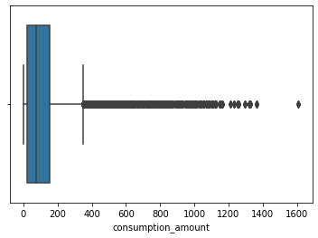

```python
# consumption_amount
sns.boxplot(x='consumption_amount',data=data);
```

```python
def remove_outliers(data, column):
    """remove the outliers of column in data
    INPUT：
    data(dataframe) - the original data;
    column(col) - the specific column of the dataframe

    OUTPUT:
    data_outliers_removed(dataframe) - dataframe without outliers
    """
    # identify outliers
    IQR = data[column].quantile(0.75) - data[column].quantile(0.25)
    outlier_top = data[column].quantile(0.75) + 1.5 * IQR
    outlier_bottom = data[column].quantile(0.25) - 1.5 * IQR

    # removed outliers
    data_outliers_removed = data[(data[column] < outlier_top) & (data[column] > outlier_bottom) ]
    return data_outliers_removed
```

```python
# Remove the outliers of income and comsumption_amount
data = remove_outliers(data, 'income')
data = remove_outliers(data, 'consumption_amount')
```

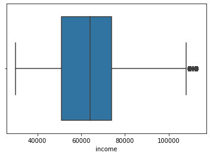

```python
# income outliers removed
sns.boxplot(x='income',data=data);
```

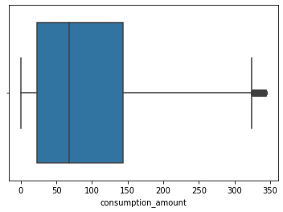

```python
# consumption_amount outliers removed
sns.boxplot(x='consumption_amount',data=data);
```

## Data Split

```python
columns_to_keep = ['age', 'income', 'reward', 'difficulty', 'duration', 'web', 'email', 'mobile', 'social', \
                  'received_cnt', 'viewed_cnt', 'gender_F', 'gender_M',\
                  'offer_type_bogo', 'offer_type_discount', 'offer_type_informational', 'member_duration_days','consumption_avg']
data = data[columns_to_keep]
```

```python
X = data.drop('consumption_avg', axis=1)
y = data['consumption_avg']

X_train, X_test, y_train, y_test = train_test_split(X, y, test_size=0.2)
```

## Normalization

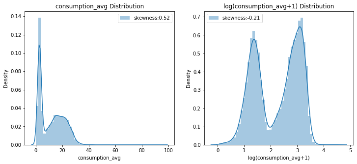

```python
# check the distribution of consumption_amount
fig = plt.figure(figsize=(12,5))
ax1 = fig.add_subplot(121)
ax2 = fig.add_subplot(122)

# compare the distributions
g1 = sns.distplot(data['consumption_avg'],hist = True,label='skewness:{:.2f}'.format(data['consumption_avg'].skew()),ax = ax1)
g1.legend()
g1.set(xlabel = 'consumption_avg', ylabel = 'Density', title = 'consumption_avg Distribution')
g2 = sns.distplot(np.log1p(data['consumption_avg']),hist = True,label='skewness:{:.2f}'.format(np.log1p(data['consumption_avg']).skew()),ax=ax2)
g2.legend()
g2.set(xlabel = 'log(consumption_avg+1)',ylabel = 'Density', title = 'log(consumption_avg+1) Distribution');
```

log1p can reduce skewness.

```python
scaler = MinMaxScaler()

X_train_scaled = scaler.fit_transform(X_train)
X_test_scaled = scaler.transform(X_test)

y_train_scaled = np.log1p(y_train)
y_test_scaled = np.log1p(y_test)
```

## Measurement

```python
#measurement
def rmse(y, yhat):
    """This function can be used to create the RMPE.

    INPUT:
        y: the true values.
        yhat: the predicted values.
    OUTPUT:
        the value of rmpe
    """
    return np.sqrt(np.mean((yhat-y) ** 2))

def rmspe(y, yhat):
    """This function can be used to create the RMSPE.

    INPUT:
        y: the true values.
        yhat: the predicted values.
    OUTPUT:
        the value of rmspe
    """
    return np.sqrt(np.mean((yhat/y-1) ** 2))

def rmspe_xg(yhat, y):
    """This function can be used to create the RMSPE with xgboost model.

    INPUT:
        y: the result of xgboost model.
        yhat: the predicted values.
    OUTPUT:
        the value of rmspe
    """
    y = np.expm1(y.get_label())
    yhat = np.expm1(yhat)
    return "rmspe", rmspe(y, yhat)
```

## LinearRegression

```python
# model fit
lr = sm.OLS(y_train_scaled ,X_train_scaled).fit()
lr.summary()

lr = LinearRegression()
# fit the model
lr.fit(X_train_scaled, y_train_scaled)

#mesurement
y_pred = lr.predict(X_test_scaled)
error1 = rmse(np.expm1(y_test_scaled), np.expm1(y_pred))
error2 = rmspe(np.expm1(y_test_scaled), np.expm1(y_pred))
score = r2_score(np.expm1(y_test_scaled), np.expm1(y_pred))
print('RMSE: {:.4f}'.format(error1))
print('RMSPE: {:.4f}'.format(error2))
print('R2: {:.4f}'.format(score))
```

```
RMSE: 5.6541
RMSPE: 1.4719
R2: 0.6065
```

## RamdomForestRegressor

```python
#Random Forest Model
from sklearn.ensemble import RandomForestRegressor

#start time
s_time = dt.datetime.now()

#fit the model
rfr = RandomForestRegressor(n_estimators = 15)
rfr.fit(X_train_scaled, y_train_scaled)

#mesurement
y_pred = rfr.predict(X_test_scaled)
error1 = rmse(np.expm1(y_test_scaled), np.expm1(y_pred))
error2 = rmspe(np.expm1(y_test_scaled), np.expm1(y_pred))
score = r2_score(np.expm1(y_test_scaled), np.expm1(y_pred))
print('RMSE: {:.4f}'.format(error1))
print('RMSPE: {:.4f}'.format(error2))
print('R2: {:.4f}'.format(score))

#end time
e_time = dt.datetime.now()
print('Time Cost：{}seconds'.format((e_time-s_time).seconds))

#save the model
joblib.dump(rfr, 'saved_model/RandomForest.pkl')
print('Model saved：{}'.format('RandomForest'))
```

```
RMSE: 3.3944
RMSPE: 1.1562
R2: 0.8582
Time Cost：3seconds
Model saved：RandomForest
```

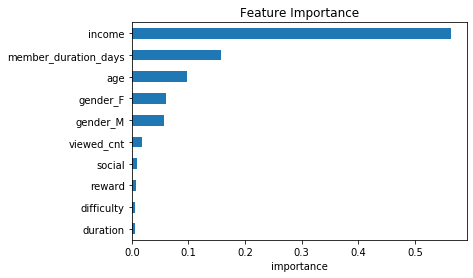

```python
# The most important 10 features
feat_importances = pd.Series(rfr.feature_importances_, index=X_train.columns)
feat_importances.nlargest(10).sort_values(ascending = True).plot(kind='barh')
plt.xlabel('importance')
plt.title('Feature Importance');
```

## XGB

### Original

```python
# start time
s_time = dt.datetime.now()

params = {"objective": "reg:linear",
          "booster" : "gbtree",
          "eta": 0.03,
          "max_depth": 10,
          "subsample": 0.9,
          "colsample_bytree": 0.7,
          "silent": 1,
          "seed": 10
          }
#num of train times
num_boost_round = 4000

dtrain = xgb.DMatrix(X_train_scaled, y_train_scaled)
dtest = xgb.DMatrix(X_test_scaled, y_test_scaled)
watchlist = [(dtrain, 'train'), (dtest, 'test')]

#fit the model
model = xgb.train(params, dtrain, num_boost_round, evals=watchlist, \
  early_stopping_rounds= 100, feval=rmspe_xg, verbose_eval=True)

#measurement
y_pred = model.predict(dtest)
error1 = rmse(np.expm1(y_test_scaled), np.expm1(y_pred))
error2 = rmspe(np.expm1(y_test_scaled), np.expm1(y_pred))
score = r2_score(np.expm1(y_test_scaled), np.expm1(y_pred))
print('RMSE: {:.4f}'.format(error1))
print('RMSPE: {:.4f}'.format(error2))
print('R2: {:.4f}'.format(score))

#end time
e_time = dt.datetime.now()
print('time cost：{}seconds'.format((e_time-s_time).seconds))

#save model
joblib.dump(model, 'saved_model/xgb.pkl')
print('Model Saved：{}'.format('xgb'))
```

```
Multiple eval metrics have been passed: 'test-rmspe' will be used for early stopping.

Will train until test-rmspe hasn't improved in 100 rounds.
Stopping. Best iteration:

RMSE: 4.3652
RMSPE: 1.0440
R2: 0.7655
time cost：13seconds
Model Saved：xgb
```

### learning_rate 0.025

```python
# start time
s_time = dt.datetime.now()

params = {"objective": "reg:linear",
          "booster" : "gbtree",
          "eta": 0.025,
          "max_depth": 10,
          "subsample": 0.9,
          "colsample_bytree": 0.7,
          "silent": 1,
          "seed": 10
          }
#num of train times
num_boost_round = 4000

dtrain = xgb.DMatrix(X_train_scaled, y_train_scaled)
dtest = xgb.DMatrix(X_test_scaled, y_test_scaled)
watchlist = [(dtrain, 'train'), (dtest, 'test')]

#fit the model
model = xgb.train(params, dtrain, num_boost_round, evals=watchlist, \
  early_stopping_rounds= 100, feval=rmspe_xg, verbose_eval=True)

#measurement
y_pred = model.predict(dtest)
error1 = rmse(np.expm1(y_test_scaled), np.expm1(y_pred))
error2 = rmspe(np.expm1(y_test_scaled), np.expm1(y_pred))
score = r2_score(np.expm1(y_test_scaled), np.expm1(y_pred))
print('RMSE: {:.4f}'.format(error1))
print('RMSPE: {:.4f}'.format(error2))
print('R2: {:.4f}'.format(score))

#end time
e_time = dt.datetime.now()
print('time cost：{}seconds'.format((e_time-s_time).seconds))

#save model
joblib.dump(model, 'saved_model/xgb025.pkl')
print('Model Saved：{}'.format('xgb'))
```

```
Multiple eval metrics have been passed: 'test-rmspe' will be used for early stopping.

Will train until test-rmspe hasn't improved in 100 rounds.
Stopping. Best iteration:

RMSE: 4.7214
RMSPE: 1.0363
R2: 0.7256
time cost：12seconds
Model Saved：xgb
```

### learning_rate 0.02

```python
# start time
s_time = dt.datetime.now()

params = {"objective": "reg:linear",
          "booster" : "gbtree",
          "eta": 0.02,
          "max_depth": 10,
          "subsample": 0.9,
          "colsample_bytree": 0.7,
          "silent": 1,
          "seed": 10
          }
#num of train times
num_boost_round = 4000

dtrain = xgb.DMatrix(X_train_scaled, y_train_scaled)
dtest = xgb.DMatrix(X_test_scaled, y_test_scaled)
watchlist = [(dtrain, 'train'), (dtest, 'test')]

#fit the model
model = xgb.train(params, dtrain, num_boost_round, evals=watchlist, \
  early_stopping_rounds= 100, feval=rmspe_xg, verbose_eval=True)

#measurement
y_pred = model.predict(dtest)
error1 = rmse(np.expm1(y_test_scaled), np.expm1(y_pred))
error2 = rmspe(np.expm1(y_test_scaled), np.expm1(y_pred))
score = r2_score(np.expm1(y_test_scaled), np.expm1(y_pred))
print('RMSE: {:.4f}'.format(error1))
print('RMSPE: {:.4f}'.format(error2))
print('R2: {:.4f}'.format(score))

#end time
e_time = dt.datetime.now()
print('time cost：{}seconds'.format((e_time-s_time).seconds))

#save model
joblib.dump(model, 'saved_model/xgb02.pkl')
print('Model Saved：{}'.format('xgb'))
```

```
Multiple eval metrics have been passed: 'test-rmspe' will be used for early stopping.

Will train until test-rmspe hasn't improved in 100 rounds.
Stopping. Best iteration:

RMSE: 5.2720
RMSPE: 1.0165
R2: 0.6579
time cost：12seconds
Model Saved：xgb
```